# R Graphics

# base, grid, lattice, ggplot2

# Scatter Plots

## base

- plot() function
- col, pch parameters to adjust colour and style

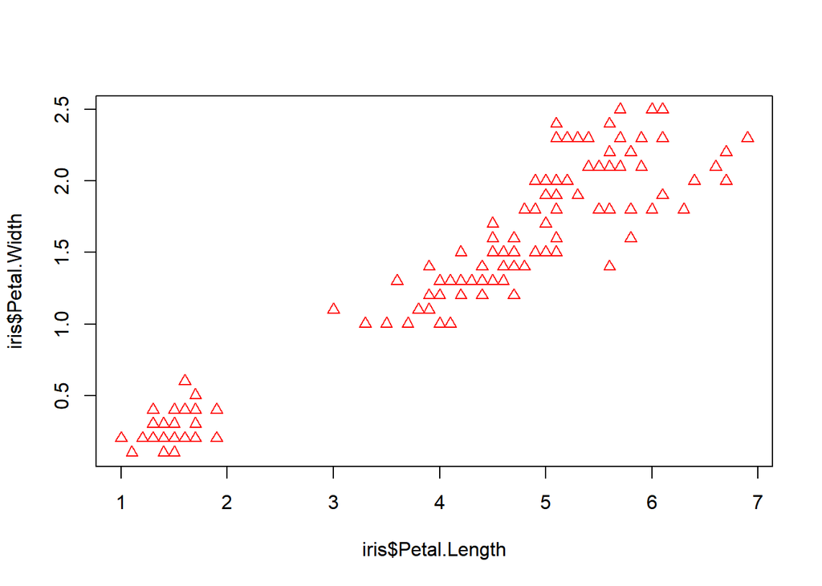

```r
plot(iris$Petal.Length, iris$Petal.Width,
     col = "red", pch = 2)
```

- Use layout() function to display multiple graphics

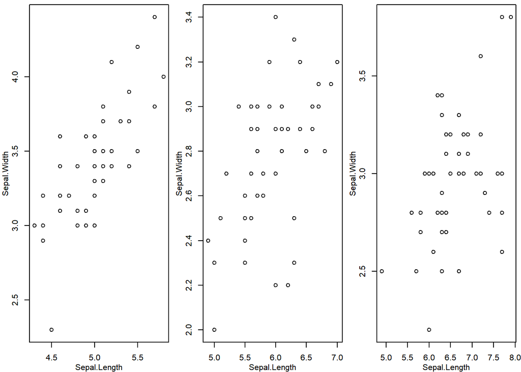

```r
par(mar = c(3, 3, 0.5, 0.5), oma = rep.int(0, 4), mgp = c(2, 1, 0))
species = levels(iris$Species)
plot_numbers = seq_along(species)
layout(matrix(plot_numbers, ncol = 3, byrow = TRUE))
for(s in species) {
  data.by.species = subset(iris, Species == s)
  with(data.by.species, plot(Sepal.Length, Sepal.Width))
}
```

## lattice

- xyplot()

## ggplot2

- ggplot() function with parameter geom_plot()

# Line Plots

## base

- plot() function with parameter type = “1”
- lines() function to add additional line

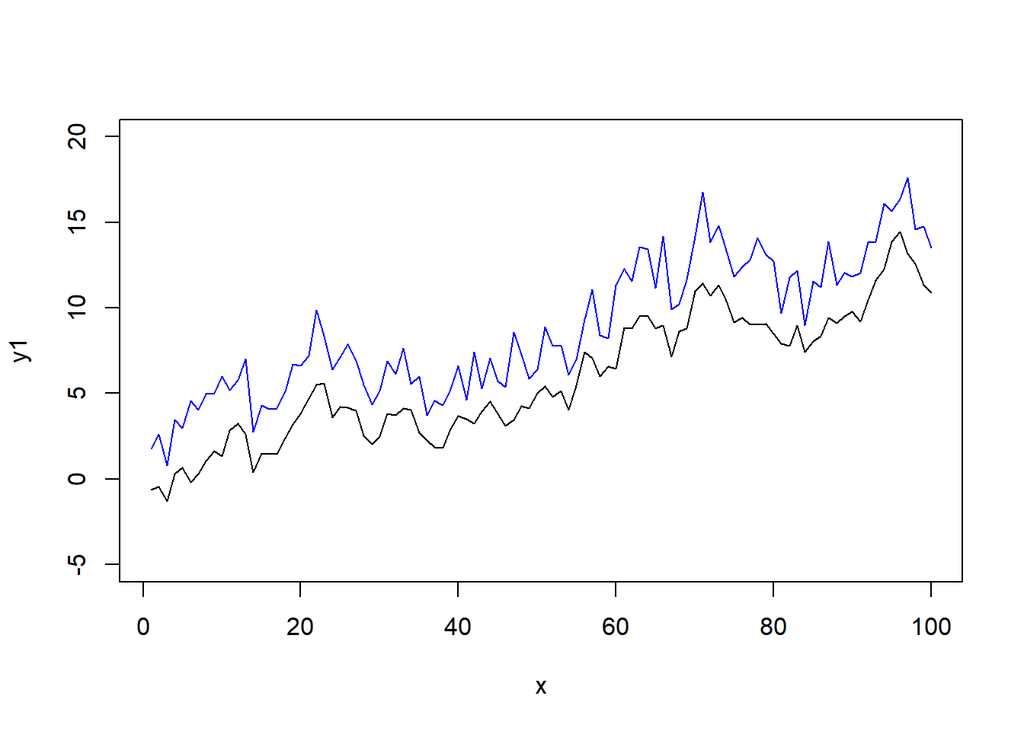

```r
set.seed(1)
y1 <- cumsum(rnorm(100))
x <- seq_along(y1)
plot(x, y1, type = "l", ylim = c(-5, 20))
y2 <- y1 + abs(rnorm(100, 3))
lines(x, y2, col = "blue")
```

## lattice

- xyplot() function with parameter type = “1”

## ggplot2

- ggplot() function with parameter geom_line()

# Histograms

## base

- hist() function
- Add parameter freq = FALSE if want to have total area = 1
- Add parameter breaks to define number of bar

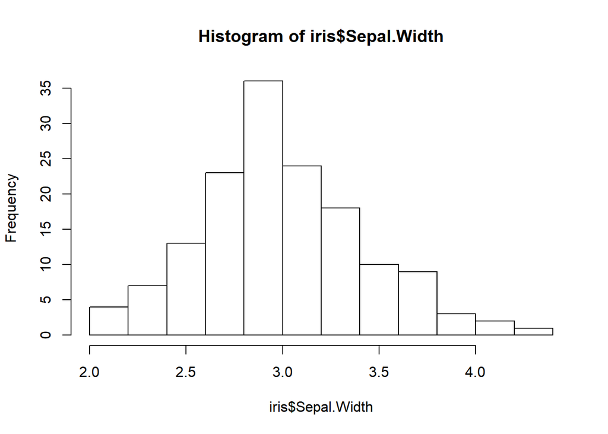

```r
hist(iris$Sepal.Width)
```

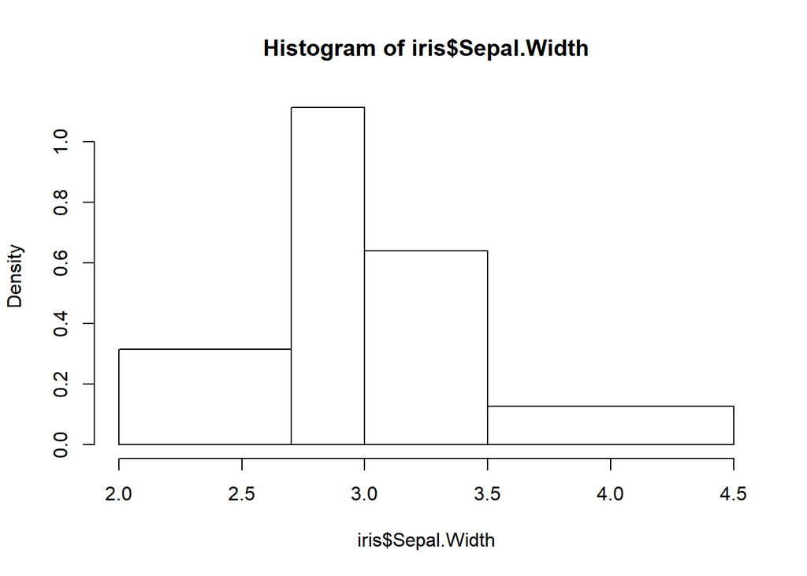

```r
hist(iris$Sepal.Width, breaks = c(2, 2.7, 3, 3.5, 4.5))
```

## lattice

- histogram() function
- y axis adjust by parameter type
- 3 types can be choose: percent, count, density
- parameter break is the same as hist() function

## ggplot2

- ggplot() function with parameter geom_histogram()
- Parameter bins in geom_histogram() can define number of bin

# Box Plots

## base

- boxplot() function

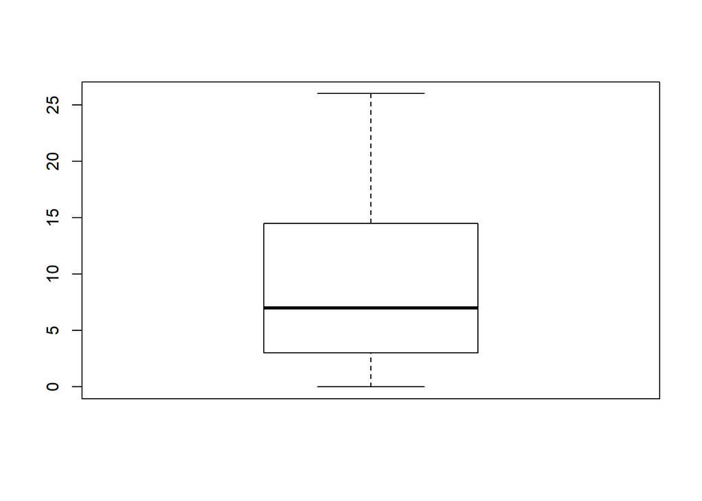

```r
boxplot(InsectSprays$count)
```

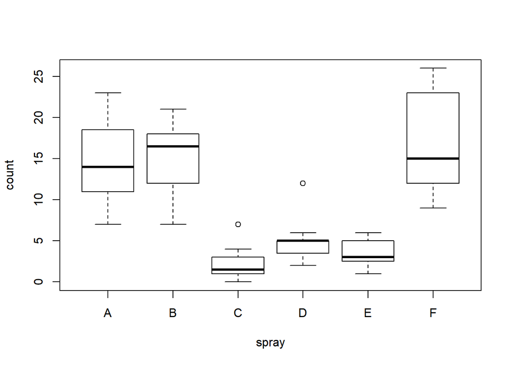

```r
# draw for count according to spray
boxplot(count ~ spray, data = InsectSprays)
```

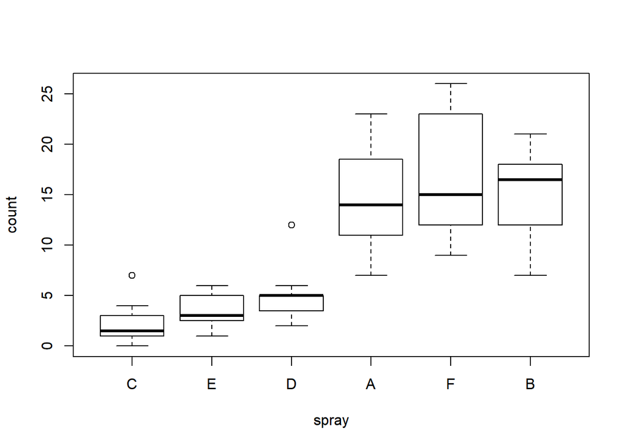

```r
# define data frame to order
my.InsectSprays <- within(InsectSprays,  spray <- (reorder(spray, count, median)))
boxplot(count ~ spray, data = my.InsectSprays)
```

## lattice

- bwplot() function
- Similar to boxplot() function

## ggplot2

- ggplot() function with parameter geom_boxplot()

# Bar Plots

## base

- barplot() function
- Use parameter names.arg to define the name of each bar
- Use parameter horiz = TRUE to switch to horizontal bar
- Word orientation have to apply par(las = 1, mar = c(3, 5, 1, 1))
- las = 1 means horizontal
- mar means margin from below, left, top to right

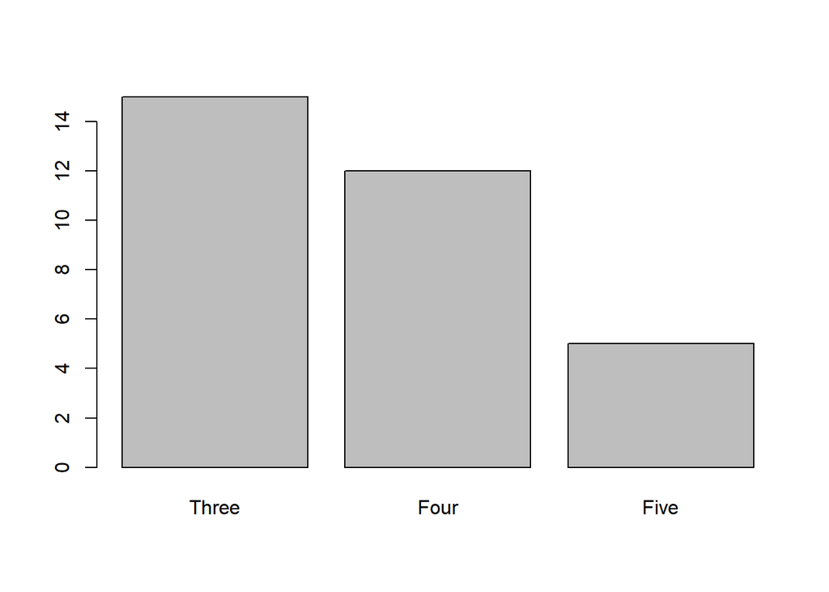

```r
gear.table <- table(mtcars$gear)
barplot(gear.table, names.arg = c("Three", "Four", "Five"))
```

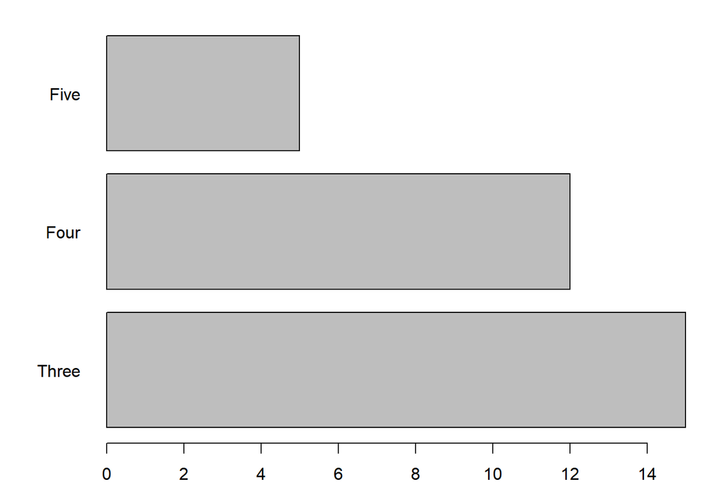

```r
par(las = 1, mar = c(3, 5, 1, 1))
barplot(gear.table, names.arg = c("Three", "Four", "Five"), horiz = TRUE)
```

- Combine to data set in one chart
- Add parameter beside = TRUE to seperate

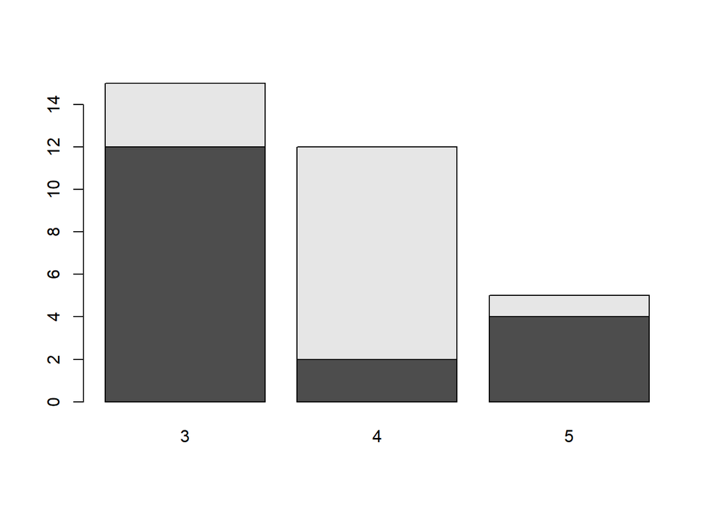

```r
gear.table2 <- table(mtcars$vs, mtcars$gear)
barplot(gear.table2)
```

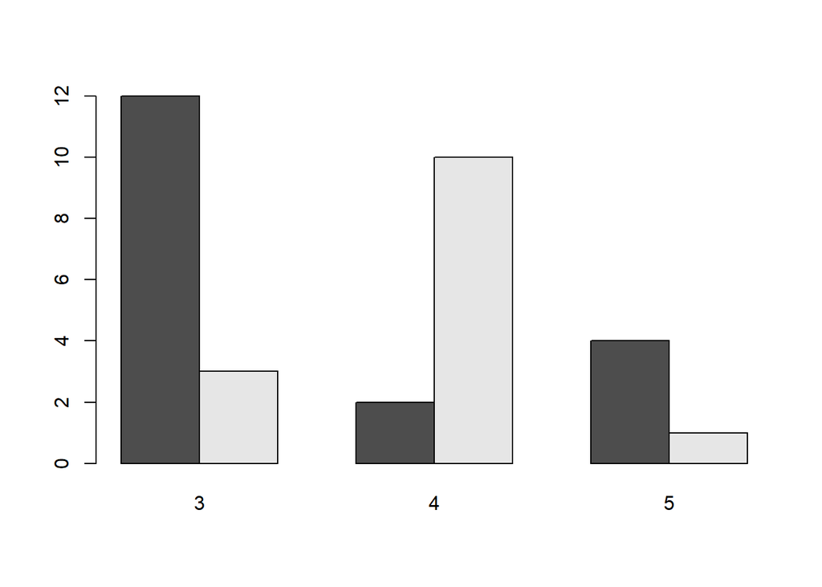

```r
barplot(gear.table2, beside = TRUE)
```

## lattice

- barchart() function
- Add parameter stack = FALSE to seperate bars

## ggplot2

- ggplot() function with parameter geom_bar()
- Add parameter position = “dodge” in geom_bar() to split bars
- Add parameter coord_flip() to create horizontal bar

# Pie chart

## base

- pie() function
- Use par(mar = c(1 ,1 ,1 ,1)) to control size
- Add parameter labels to define names

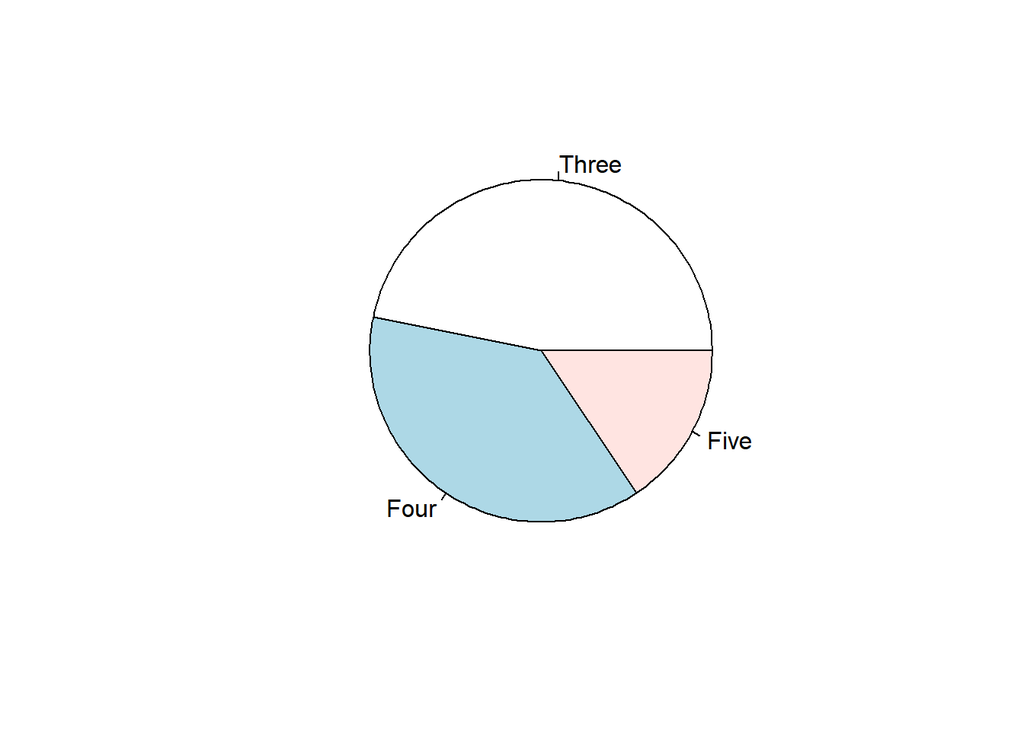

```r
pie(gear.table, labels = c("Three", "Four", "Five"))
```

## lattice

- No Function Provided

## ggplot2

- Create by combining bar chat and then cut to circle
- Use coord_polar to transform
- Add theme_void to hide axes of bar chart
- Syntax as below

```r
pie <- ggplot(mtcars,
  aes(x = factor(1), fill = factor(gear))) +
  geom_bar(width = 1)
pie # create bar chart
pie <- pie + coord_polar(theta = "y")
pie # transform to circular shape
pie <- pie + theme_void()
pie # hide axes
```

# Other plotting packages

- vcd:
- plotrix:
- hexbin:
- scatterplot3d:
- misc3d:
- rgl: Use OpenGL to plot 3D graph
- rggob: Use GGobi in R
- igraph:
- plotly: Plotly for R
- Check plotting packages from CRAN Task View